# Pacific giant salamanders in Mack Creek

### Results D: Is there a significant difference in mean weights for Pacific giant salamanders observed in clear cut vs old growth forests in 2017

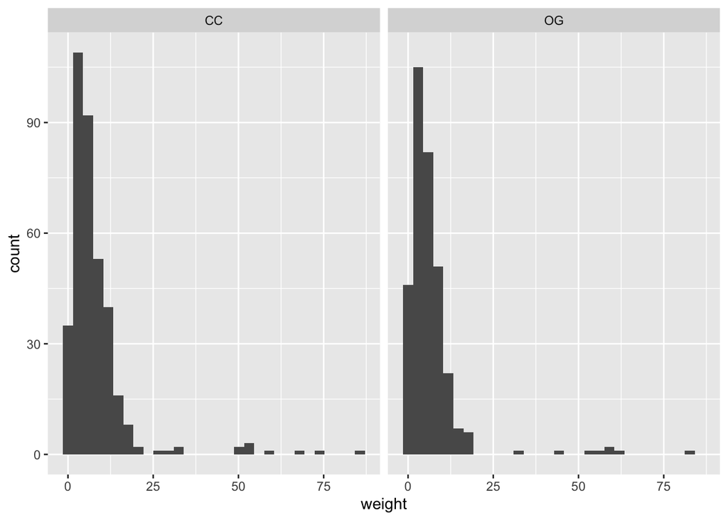

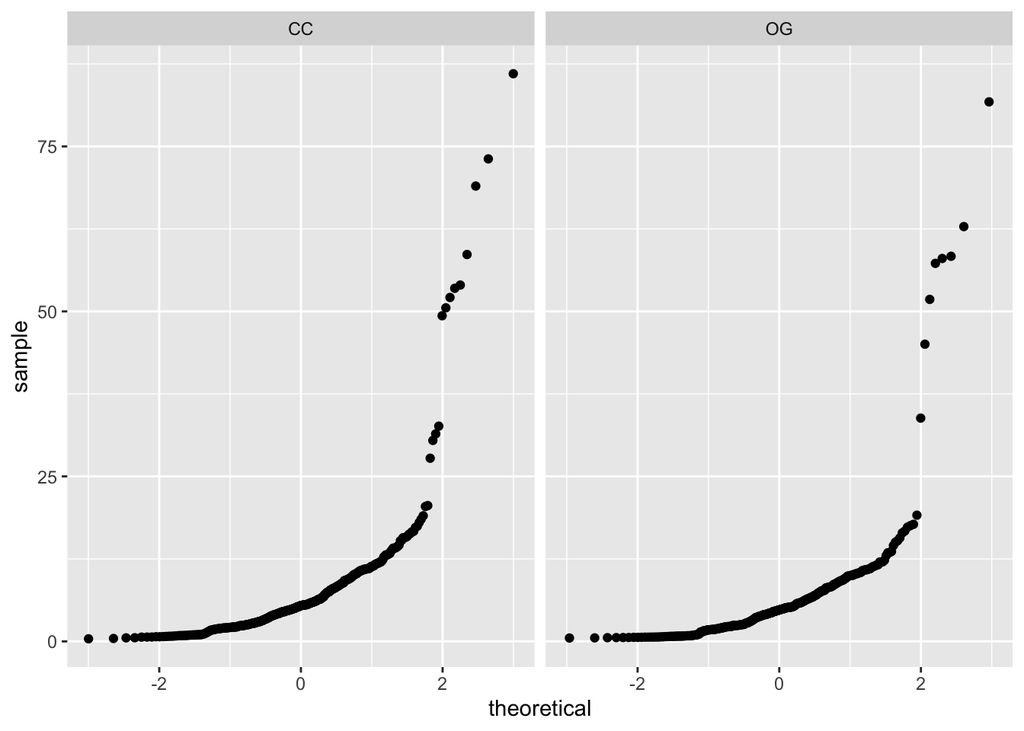

```
##
##  Welch Two Sample t-test
##
## data:  weight by section
## t = 1.6669, df = 692.79, p-value = 0.09599
## alternative hypothesis: true difference in means is not equal to 0
## 95 percent confidence interval:
##  -0.2121307  2.5972032
## sample estimates:
## mean in group CC mean in group OG
##         7.775870         6.583333
```

### Results E: Is there a significant difference between mean Pacific giant salamander weights in the 3 channel types: pools, cascades and side-channels of Mack Creek in 2017?

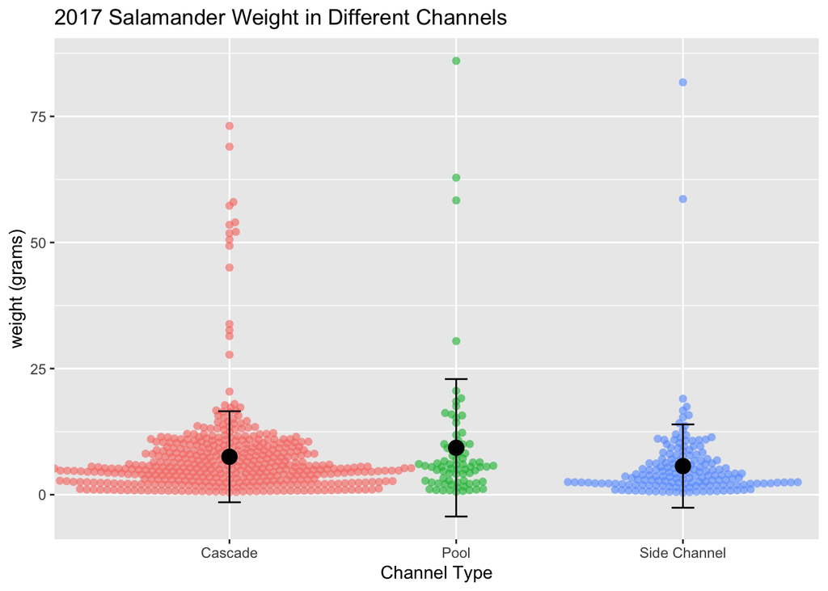

```
##               Df Sum Sq Mean Sq F value Pr(>F)
## channel_type   2    757   378.4   4.216 0.0151 *
## Residuals    684  61403    89.8
## ---
## Signif. codes:  0 '***' 0.001 '**' 0.01 '*' 0.05 '.' 0.1 ' ' 1
## 1 observation deleted due to missingness
```

### References

**Gregory S. V. 2016**. Aquatic Vertebrate Population Study in Mack Creek, Andrews Experimental Forest, 1987 to present. Environmental Data Initiative. https://doi.org/10.6073/pasta/5de64af9c11579266ef20da2ff32f702. Dataset accessed 11/25/2019.